# Part I - (Dataset Prosper Loan Data)

## Introduction to the Prosper Loan Dataset

In this project, we will analyze the **Prosper Loan Dataset**, a collection of data from *Prosper Marketplace*, a peer-to-peer lending platform.

The dataset contains information on **over 100,000 loans**, with more than 80 variables describing:

- **Loan characteristics** – original loan amount, term, interest rate (BorrowerAPR), and current loan status (LoanStatus).
- **Borrower characteristics** – Prosper score, income range, employment status.
- **Loan performance** – amount paid, outstanding principal, late payments, or defaults.
- **Listing details** – category of the listing (ListingCategory), origination date, and credit risk rating.

## Preliminary Wrangling

```python
# import all packages and set plots to be embedded inline
import numpy as np
import pandas as pd
import matplotlib.pyplot as plt
import seaborn as sns

%matplotlib inline
```

```python
# high-level overview of data shape and composition

loans = pd.read_csv('data/prosperLoanData.csv')

print(loans.shape)
print(loans.dtypes)
print(loans.head(4))
```

```
(113937, 81)
ListingKey                      object
ListingNumber                    int64
ListingCreationDate             object
CreditGrade                     object
Term                             int64
                                ...
PercentFunded                  float64
Recommendations                  int64
InvestmentFromFriendsCount       int64
InvestmentFromFriendsAmount    float64
Investors                        int64
Length: 81, dtype: object
                ListingKey  ListingNumber            ListingCreationDate  \
0  1021339766868145413AB3B         193129  2007-08-26 19:09:29.263000000
1  10273602499503308B223C1        1209647  2014-02-27 08:28:07.900000000
2  0EE9337825851032864889A          81716  2007-01-05 15:00:47.090000000
3  0EF5356002482715299901A         658116  2012-10-22 11:02:35.010000000

  CreditGrade  Term LoanStatus           ClosedDate  BorrowerAPR  \
0           C    36  Completed  2009-08-14 00:00:00      0.16516
1         NaN    36    Current                  NaN      0.12016
2          HR    36  Completed  2009-12-17 00:00:00      0.28269
3         NaN    36    Current                  NaN      0.12528

   BorrowerRate  LenderYield  ...  LP_ServiceFees  LP_CollectionFees  \
0        0.1580       0.1380  ...         -133.18                0.0
1        0.0920       0.0820  ...            0.00                0.0
2        0.2750       0.2400  ...          -24.20                0.0
3        0.0974       0.0874  ...         -108.01                0.0

   LP_GrossPrincipalLoss  LP_NetPrincipalLoss LP_NonPrincipalRecoverypayments  \
0                    0.0                  0.0                             0.0
1                    0.0                  0.0                             0.0
2                    0.0                  0.0                             0.0
3                    0.0                  0.0                             0.0

   PercentFunded  Recommendations InvestmentFromFriendsCount  \
0            1.0                0                          0
1            1.0                0                          0
2            1.0                0                          0
3            1.0                0                          0

  InvestmentFromFriendsAmount Investors
0                         0.0       258
1                         0.0         1
2                         0.0        41
3                         0.0       158

[4 rows x 81 columns]
```

### What is the structure of your dataset?

Columns include:

- Loan characteristics (e.g., `LoanOriginalAmount`, `Term`, `LoanStatus`, `BorrowerAPR`),
- Borrower information (e.g., `ProsperScore`, `IncomeRange`, `EmploymentStatus`),
- Loan performance details (e.g., `ClosedDate`, `LoanCurrentDaysDelinquent`).

### What is/are the main feature(s) of interest in your dataset?

The main features of interest are:

- **BorrowerAPR** (interest rate): to study its distribution and what factors influence it.
- **LoanStatus**: to understand the performance of loans and the proportion of completed, current, and defaulted loans.
- **LoanOriginalAmount**: to analyze the distribution of loan amounts and how they relate to income or ProsperScore.
- **ProsperScore**: as a key indicator of credit risk and a potential driver of interest rate differences.

### What features in the dataset do you think will help support your investigation into your feature(s) of interest?

To investigate the main features, I will use:

- **IncomeRange** and **EmploymentStatus** to see if socioeconomic factors affect interest rates or loan amounts.
- **Term** to analyze whether longer terms correlate with higher interest rates or defaults.
- **ListingCategory (numeric)** to explore differences between loan purposes.
- **BorrowerState** to see if geographic factors play a role in loan performance.
- **ProsperScore** to check its relationship with BorrowerAPR and LoanStatus.

## Univariate Exploration

### Question 1

What are the socio-economic condition of loaners and how the interest rate may relate to it?

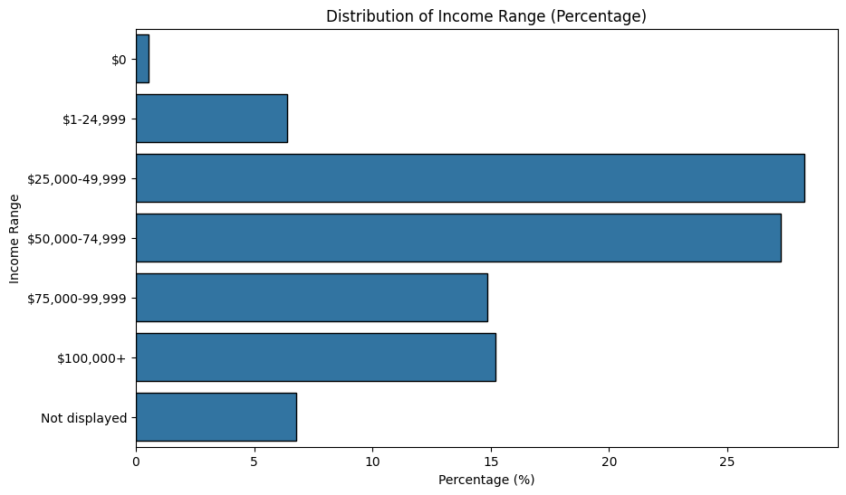

```python
a = loans['IncomeRange'].value_counts()
tot = a.sum()


income_range = [
    '$0', '$1-24,999', '$25,000-49,999', '$50,000-74,999',
    '$75,000-99,999', '$100,000+', 'Not displayed'
]
income_pct = (a / tot * 100).reindex(income_range)

plt.figure(figsize=(10, 6))
sns.barplot(x=income_pct.values, y=income_pct.index,  edgecolor='black')
plt.title('Distribution of Income Range (Percentage)')
plt.xlabel('Percentage (%)')
plt.ylabel('Income Range')
plt.show()
```

### Observation: Distribution of Income Range

The distribution of `IncomeRange` shows that the majority of borrowers report an income between **$25,000–74,999** (over 50% combined).  
Only **~6% of borrowers did not disclose their income ("Not displayed")**.

Since the "Not displayed" category represents a very small portion of the dataset and does not provide meaningful information for socio-economic analysis, I will **consider dropping these rows** to avoid noise and improve the quality of further visualizations.

> **Decision:** Exclude rows with `IncomeRange = "Not displayed"` from subsequent analysis.

```python
# Remove rows where IncomeRange is "Not displayed"
loans_clean = loans[loans['IncomeRange'] != 'Not displayed'].copy()
print(f"Remaining rows after filtering: {len(loans_clean)}")
```

```
Remaining rows after filtering: 106196
```

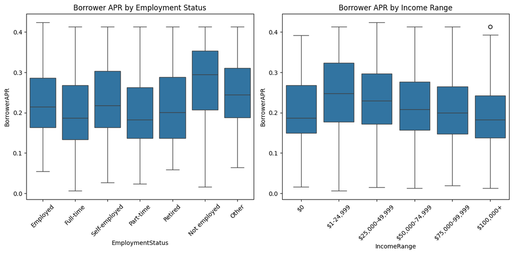

```python
income_order = [
    '$0', '$1-24,999', '$25,000-49,999', '$50,000-74,999',
    '$75,000-99,999', '$100,000+'
]
employment_order = [
    'Employed', 'Full-time', 'Self-employed', 'Part-time',
    'Retired', 'Not employed', 'Other'
]

fig, ax = plt.subplots(1, 2, figsize=(12, 6))

sns.boxplot(data=loans_clean, x='EmploymentStatus', y='BorrowerAPR', ax=ax[0], order=employment_order)
ax[0].set_title("Borrower APR by Employment Status")
ax[0].set_xticklabels(ax[0].get_xticklabels(), rotation=45)

sns.boxplot(data=loans_clean, x='IncomeRange', y='BorrowerAPR', ax=ax[1], order=income_order)
ax[1].set_title("Borrower APR by Income Range")
ax[1].set_xticklabels(ax[1].get_xticklabels(), rotation=45)

plt.tight_layout()
plt.show()
```

### Observations: Socio-Economic Analysis - Borrower APR by Employment Status and Income Range

The boxplots above provide insights into how **employment status** and **income range** relate to `BorrowerAPR` (interest rate):

**Interpretation:** These plots confirm that socio-economic factors like income and employment have a noticeable impact on loan interest rates.  
Borrowers with stable jobs and higher income ranges generally receive more favorable APRs, which aligns with expectations of lower credit risk.

### Question 2

How does the loan term (12, 36, 60 months) affect the characteristics of the loans?

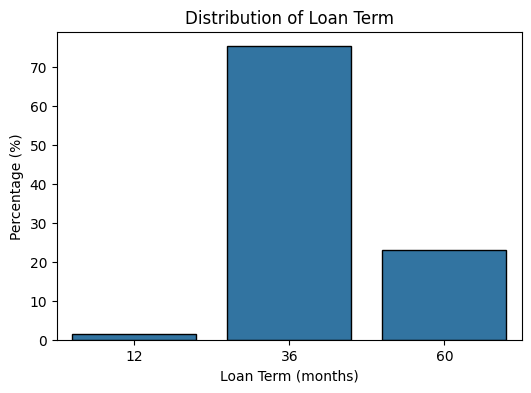

```python
loans_clean['Term'] = loans_clean['Term'].astype('category')


plt.figure(figsize=(6,4))
sns.countplot(data=loans_clean, x='Term', edgecolor='black',stat='percent')
plt.title('Distribution of Loan Term')
plt.xlabel('Loan Term (months)')
plt.ylabel('Percentage (%)')
plt.show()
```

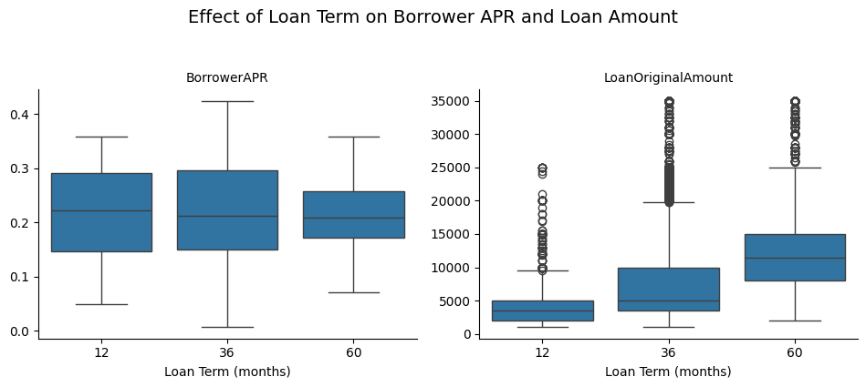

```python
# Create FacetGrid
g = sns.FacetGrid(loans_clean.melt(id_vars=['Term'], value_vars=['BorrowerAPR','LoanOriginalAmount']),
                  col="variable", sharex=False, sharey=False, height=4, aspect=1.2)

g.map_dataframe(sns.boxplot, x="Term", y="value")
g.set_axis_labels("Loan Term (months)", "")
g.set_titles("{col_name}")
g.set_xticklabels(rotation=0)

plt.suptitle("Effect of Loan Term on Borrower APR and Loan Amount", y=1.05, fontsize=14)
plt.tight_layout()
plt.show()
```

### Question 3

What is the distribution of Borrower APR (interest rate) among the loans?

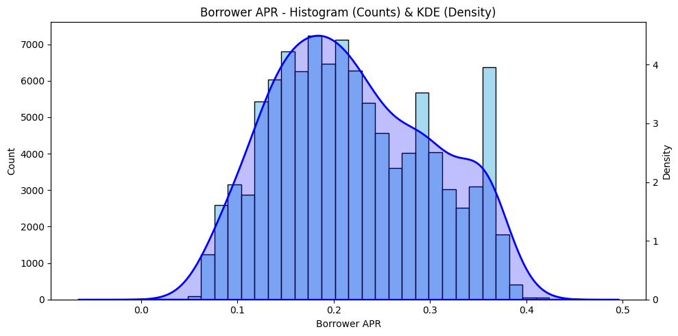

```python
fig, ax1 = plt.subplots(figsize=(10,5))

# Istogramma sui conteggi (asse sinistro)
sns.histplot(loans_clean['BorrowerAPR'], bins=30, color='skyblue', edgecolor='black', ax=ax1)
ax1.set_ylabel("Count")
ax1.set_xlabel("Borrower APR")

# Secondo asse per la densità
ax2 = ax1.twinx()
sns.kdeplot(loans_clean['BorrowerAPR'], bw_adjust=3, color='blue', fill='blue', ax=ax2, lw=2)
ax2.set_ylabel("Density")
ax2.grid(False)  # per non duplicare la griglia

plt.title("Borrower APR - Histogram (Counts) & KDE (Density)")
plt.tight_layout()
plt.show()
```

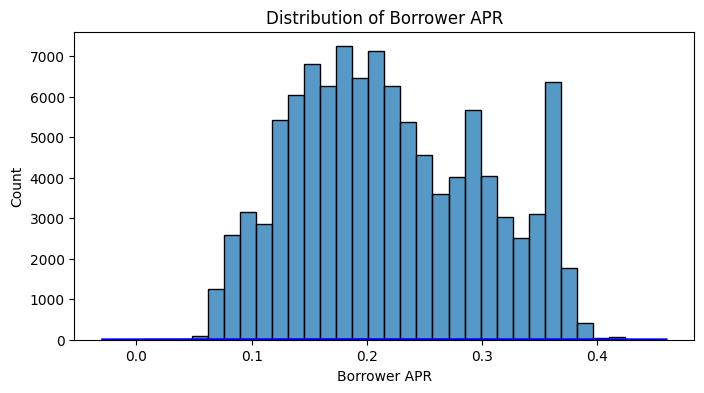

```python
plt.figure(figsize=(8, 4))
sns.histplot(data=loans_clean, x="BorrowerAPR", stat="count", bins=30)
sns.kdeplot(loans_clean['BorrowerAPR'], bw_adjust=1.5, color="blue", lw=2)
plt.title("Distribution of Borrower APR")
plt.xlabel("Borrower APR")
plt.ylabel("Count")
plt.show()
```

### Observations

- The distribution is right-skewed: most loans have APRs between **0.1 and 0.35**.
- There are a few loans with extremely low APRs (close to 0) and some very high ones (above 0.4).
- This could indicate different risk profiles or loan categories (e.g., low risk vs high risk borrowers).

### Question 4

What is the distribution of Loan Original Amount?

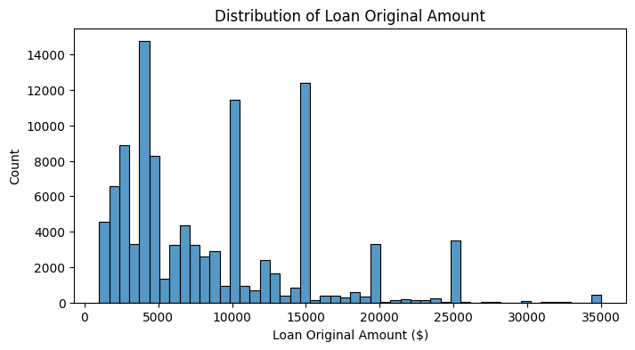

```python
plt.figure(figsize=(8, 4))
sns.histplot(data=loans_clean, x="LoanOriginalAmount", bins= 50)
plt.title("Distribution of Loan Original Amount")
plt.xlabel("Loan Original Amount ($)")
plt.ylabel("Count")
plt.show()
```

### Observations

- The distribution shows clear peaks at **common loan amounts** (e.g., $5,000, $10,000, $15,000).
- This suggests standard loan amounts are offered by Prosper rather than arbitrary values.
- The distribution is slightly right-skewed, with fewer very large loans.

### Question 5

What is the overall distribution of loan statuses and how does it relate to interest rates and risk scores?

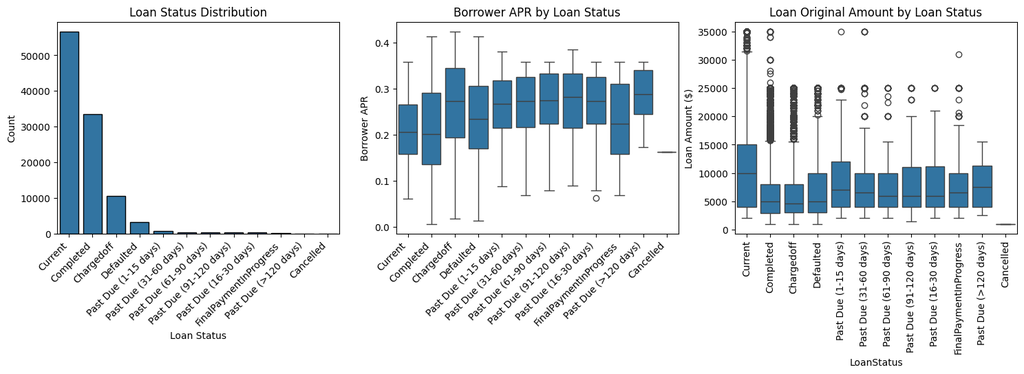

```python
plt.figure(figsize=(18, 4))


plt.subplot(1, 3, 1)
sns.countplot(data=loans_clean, x='LoanStatus', order=loans_clean['LoanStatus'].value_counts().index, edgecolor='black')
plt.xticks(rotation=45, ha='right')
plt.title('Loan Status Distribution')
plt.xlabel('Loan Status')
plt.ylabel('Count')

plt.subplot(1, 3, 2)
sns.boxplot(data=loans_clean, x='LoanStatus', y='BorrowerAPR', order=loans_clean['LoanStatus'].value_counts().index)
plt.xticks(rotation=45, ha='right')
plt.title('Borrower APR by Loan Status')
plt.xlabel('')
plt.ylabel('Borrower APR')

plt.subplot(1, 3, 3)
sns.boxplot(data=loans_clean, x='LoanStatus', y='LoanOriginalAmount', order=loans_clean['LoanStatus'].value_counts().index, )
plt.title("Loan Original Amount by Loan Status")
plt.xticks(rotation=90)
plt.ylabel("Loan Amount ($)")
plt.show()

plt.show();
```

### Question 6

What is the distribution of Prosper Score?

#### ProsperScore Missing Value Analysis

- The bar chart below shows that almost all missing values are concentrated in loans originated **before 2009**.
- After 2009, ProsperScore is consistently available, which matches the fact that Prosper introduced this score as part of their credit model in mid-2009.
- For subsequent analyses where ProsperScore is relevant, I will restrict the dataset to rows where ProsperScore is not null.

```
Missing ProsperScore: 21343 rows (20.10% of dataset)
```

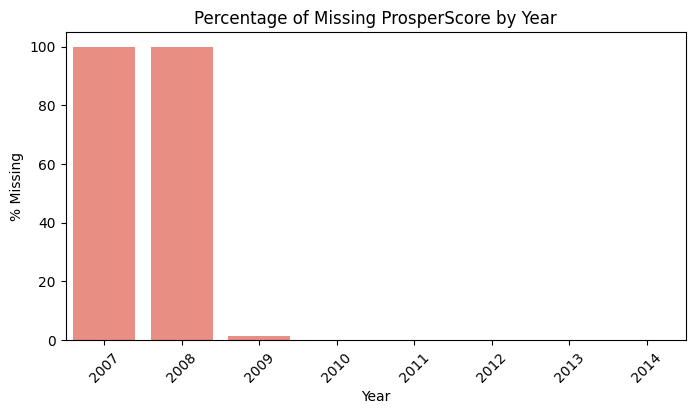

```python
# Count missing values in ProsperScore
missing_count = loans_clean["ProsperScore"].isna().sum()
total_rows = len(loans_clean)
missing_pct = missing_count / total_rows * 100

print(f"Missing ProsperScore: {missing_count} rows ({missing_pct:.2f}% of dataset)")

# Visualize proportion of missing values by year
loans_clean["year"] = pd.to_datetime(loans_clean["ListingCreationDate"], format='mixed').dt.year

missing_by_year = (
    loans_clean.groupby("year")["ProsperScore"]
    .apply(lambda x: x.isna().mean() * 100)
    .reset_index(name="pct_missing")
)

plt.figure(figsize=(8,4))
sns.barplot(data=missing_by_year, x="year", y="pct_missing", color="salmon")
plt.title("Percentage of Missing ProsperScore by Year")
plt.ylabel("% Missing")
plt.xlabel("Year")
plt.xticks(rotation=45)
plt.show()
```

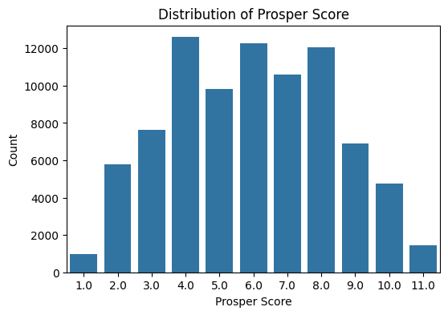

```python
sorted_out = sorted(loans_clean["ProsperScore"].dropna().unique())

plt.figure(figsize=(6, 4))
sns.countplot(data=loans_clean, x="ProsperScore", order=sorted_out)
plt.title("Distribution of Prosper Score")
plt.xlabel("Prosper Score")
plt.ylabel("Count")
plt.show()
```

### Discuss the distribution(s) of your variable(s) of interest. Were there any unusual points? Did you need to perform any transformations?

The distribution of **BorrowerAPR** is right-skewed, with most loans having APR between 0.1 and 0.35 but some extreme high values above 0.4.  
The **LoanOriginalAmount** distribution shows clear peaks at round values such as 5,000, 10,000, and 15,000 USD, indicating that Prosper offers loans in standard increments rather than arbitrary amounts.  
**ProsperScore** ranges from 1 to 11, but we observed missing values (NaN) concentrated almost entirely in loans originated before 2009.

I did not perform any mathematical transformations (e.g., log transformation) because the variables are already interpretable in their current scale.  
However, I will filter the dataset to include only loans with a valid ProsperScore for subsequent analyses, to ensure comparisons are consistent and not biased by missing values.

### Of the features you investigated, were there any unusual distributions? Did you perform any operations on the data to tidy, adjust, or change the form of the data? If so, why did you do this?

Yes — the most unusual pattern was that **ProsperScore is missing for a large number of loans before 2009**.  
This is not a random issue but rather a result of Prosper introducing this score only in mid-2009.

To avoid distorting relationships between ProsperScore and other features (such as BorrowerAPR, LoanStatus, or LoanOriginalAmount),  
I created a **filtered dataset** that excludes loans with missing ProsperScore.  
This ensures that analyses are based only on loans where ProsperScore is available and comparable.

## Bivariate Exploration

> In this section, investigate relationships between pairs of variables in your data. Make sure the variables that you cover here have been introduced in some fashion in the previous section (univariate exploration).

```python
# Create a filtered dataset with valid ProsperScore (post-2009 loans)
df_score = loans_clean[loans_clean["ProsperScore"].notna()].copy()

print(f"Original dataset: {len(loans_clean)} rows")
print(f"Filtered dataset (with ProsperScore): {len(df_score)} rows")
```

```
Original dataset: 106196 rows
Filtered dataset (with ProsperScore): 84853 rows
```

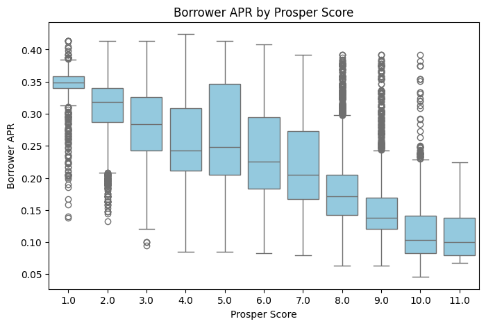

```python
plt.figure(figsize=(8,5))
sns.boxplot(data=df_score, x="ProsperScore", y="BorrowerAPR", color="skyblue")
plt.title("Borrower APR by Prosper Score")
plt.xlabel("Prosper Score")
plt.ylabel("Borrower APR")
plt.show()
```

#### Outliers weigth

```python
q1 = df_score.groupby("ProsperScore")["BorrowerAPR"].quantile(0.25)
q3 = df_score.groupby("ProsperScore")["BorrowerAPR"].quantile(0.75)
iqr = q3 - q1

outlier_mask = df_score.apply(
    lambda row: (row["BorrowerAPR"] < q1[row["ProsperScore"]] - 1.5 * iqr[row["ProsperScore"]]) |
                (row["BorrowerAPR"] > q3[row["ProsperScore"]] + 1.5 * iqr[row["ProsperScore"]]),
    axis=1
)

outlier_counts = df_score[outlier_mask].groupby("ProsperScore").size()
outlier_pct = (outlier_counts / df_score.groupby("ProsperScore").size()) * 100

print(outlier_pct)
```

```
ProsperScore
1.0     13.911290
2.0      2.306625
3.0      0.052342
4.0           NaN
5.0           NaN
6.0           NaN
7.0           NaN
8.0      3.874554
9.0      2.951816
10.0     1.305263
11.0          NaN
dtype: float64
```

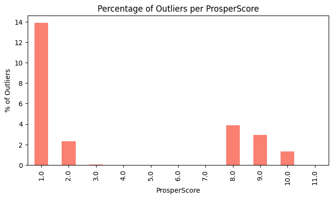

```python
outlier_pct.plot(kind="bar", color="salmon", figsize=(8,4))
plt.title("Percentage of Outliers per ProsperScore")
plt.ylabel("% of Outliers")
plt.xlabel("ProsperScore")
plt.show()
```

### Talk about some of the relationships you observed in this part of the investigation. How did the feature(s) of interest vary with other features in the dataset?

he analysis of outliers by ProsperScore reveals that extreme values are not evenly distributed:

- **ProsperScore = 1** has the **highest concentration of outliers (≈14%)**, which is unusually high. This means a significant proportion of loans in the lowest credit category have APRs that deviate strongly from the typical range for this group.
- Scores 8 and 9 also show a moderate percentage of outliers (≈3–4%), but their impact on the overall distribution is much smaller compared to ProsperScore = 1.
- Scores 4–7 have virtually no outliers, suggesting a much more stable distribution.

Because of this pattern, **the mean APR might be skewed by these extreme values**, especially for ProsperScore = 1. The **median APR** is a better measure of central tendency for comparing credit risk categories.

### Did you observe any interesting relationships between the other features (not the main feature(s) of interest)?

To further investigate relationships between features beyond my main variables of interest, I created a PairGrid using a random sample of 5,000 loans and focusing on five key variables:

- **ProsperScore**
- **BorrowerAPR**
- **LoanOriginalAmount**
- **DebtToIncomeRatio**
- **StatedMonthlyIncome**

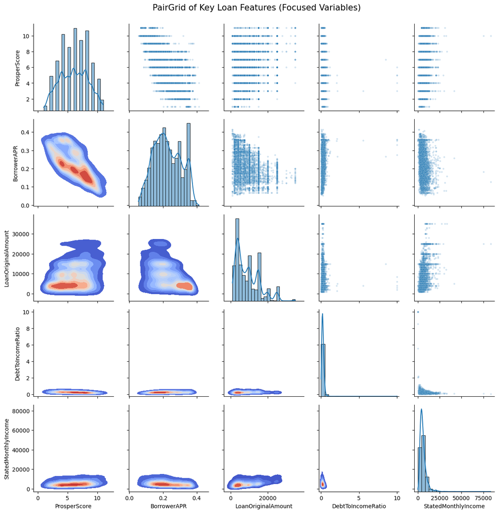

```python
cols_keys = ['ProsperScore', 'BorrowerAPR', 'LoanOriginalAmount', 'DebtToIncomeRatio', 'StatedMonthlyIncome']
df_keys = loans_clean[cols_keys].dropna()

# Prendo un campione per performance
np.random.seed(42)
sample_idx = np.random.choice(df_keys.index, size=5000, replace=False)
df_small = df_keys.loc[sample_idx]

# PairGrid piccolo
g = sns.PairGrid(df_small,diag_sharey=False, height=2.5)
g.map_upper(sns.scatterplot, alpha=0.2, s=10)
g.map_diag(sns.histplot, kde=True, bins=20)
g.map_lower(sns.kdeplot, fill=True, cmap='coolwarm')

plt.suptitle("PairGrid of Key Loan Features (Focused Variables)", y=1.02, fontsize=15)
plt.show()
```

### Talk about some of the relationships you observed in this part of the investigation. Were there features that strengthened each other in terms of looking at your feature(s) of interest?

- **ProsperScore vs BorrowerAPR** shows a strong negative relationship: higher scores are clearly associated with lower interest rates, confirming ProsperScore as a reliable credit risk indicator.
- **LoanOriginalAmount vs ProsperScore** indicates that borrowers with higher scores tend to receive slightly larger loans, though the distribution remains quite spread.
- **DebtToIncomeRatio** is highly right-skewed, with most borrowers concentrated near very low ratios; this should be considered when modeling to avoid distortion by extreme values.
- **StatedMonthlyIncome** has a long right tail with a few extreme outliers that might need capping or log transformation for modeling purposes.

Overall, this grid highlights which feature pairs have strong or potentially interesting relationships and helps prioritize variables for deeper modeling and hypothesis testing.

### Were there any interesting or surprising interactions between features?

Yes, a few interactions stood out in the multivariate analysis:

- **ProsperScore, BorrowerAPR, and LoanOriginalAmount** interact in a meaningful way:
  - Higher ProsperScores are associated with lower BorrowerAPR *and* slightly larger loans.
  - This suggests that creditworthiness not only lowers borrowing costs but also enables access to higher loan amounts.
- **DebtToIncomeRatio** shows little interaction with ProsperScore or BorrowerAPR for most borrowers, but a small group with extreme ratios (>2) tends to have higher interest rates and lower loan amounts, which might indicate higher risk being priced into the loan.
- **StatedMonthlyIncome** interacts with LoanOriginalAmount as expected: higher incomes are correlated with larger loan sizes, but the presence of extreme outliers suggests some income values might be misreported or require transformation.

Overall, the most surprising finding was how strong the negative correlation between ProsperScore and BorrowerAPR is across the entire distribution, reinforcing ProsperScore as the dominant feature for interest rate prediction.

## Conclusions

In this exploratory analysis, I investigated the Prosper Loan dataset to understand key factors influencing loan performance and borrower risk.

Below is a violin plot showing the relationship between `BorrowerAPR` and `ProsperScore`, confirming that higher scores correspond to consistently lower APR values:

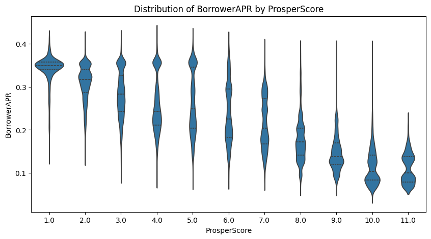

```python
plt.figure(figsize=(10,5))
sns.violinplot(data=loans_clean, x='ProsperScore', y='BorrowerAPR',  inner='quartile')
plt.title('Distribution of BorrowerAPR by ProsperScore')
plt.xlabel('ProsperScore')
plt.ylabel('BorrowerAPR')
plt.show()
```